# Temporal Discontinuity: A Quantitative Analysis of Numerology and Vedic Astrology Planetary Strength Correlation

Demonstrating Fundamental Differences in Temporal Dynamics Between Discrete and Continuous Astrological Systems

A comprehensive computational framework integrating Vedic numerology with sidereal astrology using Swiss Ephemeris calculations.

Author

Affiliation

Computational Astrology Research Group

Independent Research Initiative

Published

October 24, 2024

Abstract

Keywords

Numerology, Vedic Astrology, Planetary Strength, Nakshatra Dynamics, Computational Astrology

# 1 Master Structure

**Note**

This report is assembled from modular sections for maintainability.

# 2 Introduction

The intersection of mathematics and mythology forms the backbone of ancient predictive sciences. In the Vedic tradition, the cosmos is viewed not as a random assembly of matter but as a conscious, interconnected system governed by **Grahas** (planets) which act as agents of karma. Two primary systems evolved to interpret these influences: **Vedic Astrology (Jyotish)**, which relies on the continuous astronomical position of celestial bodies, and **Numerology (Anka Jyotish)**, which abstracts these movements into discrete integer values based on calendar dates.

## 2.1 Mythological & Archetypal Foundations

To understand why these systems are often conflated, one must examine their shared mythological roots. Each number in Vedic numerology is not merely a quantity but a symbol for a planetary deity’s energy pattern:

- **1 - The Sun (Surya)**: The soul ($Atman$), the king, the ego. Just as the Sun is the center of the solar system, the number 1 represents unity, leadership, and the self. Mythologically, Surya rides a chariot of seven horses (colors of light), representing the source of all vitality.
- **2 - The Moon (Chandra)**: The mind ($Manas$), emotions, and fluidity. Chandra is the queen, reflecting the light of the Sun. As the Moon waxes and wanes, so does the mind fluctuate.
- **3 - Jupiter (Brihaspati)**: The Guru of the Devas. Represents wisdom, expansion, and ether ($Akasha$).
- **4 - Rahu (North Node)**: The head of the demon, representing illusion ($Maya$), innovation, and unorthodoxy.
- **5 - Mercury (Budha)**: The prince, representing intellect ($Buddhi$), communication, and trade.
- **6 - Venus (Shukra)**: The Guru of the Asuras. Represents desire ($Kama$), beauty, and relationships.
- **7 - Ketu (South Node)**: The headless body, representing spiritual liberation ($Moksha$), detachment, and mystery.
- **8 - Saturn (Shani)**: The judge ($Karmakaraka$), representing discipline, delay, and truth ($Satya$).
- **9 - Mars (Mangal)**: The commander, representing energy ($Shakti$), logic, and aggression.

## 2.2 The Research Problem

Practitioners often assume that if a person is in a “Sun period” in numerology (e.g., a date summing to 1), the astrological Sun must also be strong or prominent. **This study challenges that assumption.** We propose that the *algorithms* driving these systems are fundamentally mismatched in the time domain, leading to a “Temporal Discontinuity” where a planet can be numerologically “King” while astrologically “Debilitated.”

## 2.3 Literature Review

Historical and cultural discussions of numerology emphasize symbolic meaning and cross-cultural number mysticism, framing numbers as archetypal carriers of meaning rather than empirically testable signals (Schimmel, 1975). Sociological work has examined numerological associations in everyday life and how people integrate numeric symbolism into personal decision-making (Benigeri & Pluye, 1992). Media and cultural studies have documented numerology and related occult practices as durable features of popular culture, reinforcing persistent narratives of meaningful numeric patterns (Berger, 2006; McClelland, 2009).

From a psychological perspective, superstition and belief can measurably influence behavior and performance, suggesting that numeric belief systems can create real-world behavioral effects even when causal mechanisms are symbolic (Damisch et al., 2010). Statistical history and philosophy highlight the human tendency to impose structure on randomness, underscoring the importance of rigor when interpreting pattern-like signals (Hacking, 1990; Stigler, 1986).

Methodologically, computational pattern analysis and signal comparison draw on modern statistical learning and data science foundations (Bishop, 2006). The analysis pipeline in this study leverages standard scientific computing tools for reproducibility and visualization (Hunter, 2007; McKinney et al., 2010; Pedregosa et al., 2011), and follows a literate, transparent reporting approach for replicable research workflows (Knuth, 1984).

This paper extends prior interpretive narratives by framing numerology and astrology as **distinct time-domain signals**, subject to the same alignment and frequency tests used in empirical time-series analysis.

## 2.4 Research Questions & Hypotheses

We formalize the investigation into testable hypotheses:

- **RQ1**: How often does the numerological ruling planet match the Moon’s Nakshatra lord on the same day?
- **RQ2**: Are any months or seasons more aligned than others?
- **RQ3**: Do numerology and astrology exhibit similar frequency signatures in the time domain?

**H1 (Null)**: Numerology-astrology alignment occurs at random chance (~11.1%). **H2 (Alternative)**: Alignment is significantly higher than chance, indicating synchronous operation.

# 3 Mathematical & Computational Methodology

Our research employs a rigorous computational pipeline to model both systems simultaneously.

## 3.1 Data Sources & Experimental Design

We intentionally use **daily sampling** to respect numerology’s discrete granularity and compare it directly to the Moon’s ruling Nakshatra lord.

## 3.2 Athlete Name + Birthdate Dataset

To test **name-based numerology** against **birth-based numerology**, we use a sampled athlete dataset with name and birth date fields (N=500). This enables correlation analysis between expression numbers and life-path numbers.

Dataset: `use_cases/numerology/research_paper/data/athletes_sample.csv` (source: Repository (2024))

## 3.3 Numerology Algorithm: Modulo-9 Arithmetic

Vedic numerology uses a base-9 system. The “Mulanka” (Root Number) is the most rapidly changing daily indicator. It is derived from the day of the month ($D$) using digital root summation, which is mathematically equivalent to modulo-9 arithmetic (with 9 replacing 0).

The algorithm for the Ruling Planet $P_{num}$ on day $D$ is:

$$V = (D - 1) \bmod 9 + 1$$

Where $V$ maps to the planet list: $\{1 \to Sun, 2 \to Moon, \dots, 9 \to Mars\}$. This function is a **discrete step function** $f(t)$ that holds a constant integer value for 24 hours (or until the next calendar sunrise).

## 3.4 Astrology Algorithm: Continuous Celestial Mechanics

Vedic Astrology requires determining the precise position of planets on the Ecliptic. We utilize the **Swiss Ephemeris (DE431)** for high-precision calculations.

The continuous position function $\lambda_p(t)$ for a planet $p$ at time $t$ involves: 1. **Heliocentric Calculation**: $r(t)$ vector from Sun to Planet. 2. **Geocentric Conversion**: Adjusting for Earth’s position. 3. **Sidereal Adjustment (Ayanamsa)**: Subtracting the precession of equinoxes using the Lahiri Ayanamsa ($\alpha \approx 24^\circ$).

$$\lambda_{sidereal}(t) = \lambda_{tropical}(t) - \alpha(t)$$

### 3.4.1 The Moon’s Vital Role: Nakshatras

The Moon is the fastest-moving body, traversing the zodiac in ~27.3 days. In Vedic Astrology, the zodiac is divided into 27 **Nakshatras** (Lunar Mansions) of $13^\circ 20'$ each.

The Nakshatra index $N$ is calculated as:

$$N = \lfloor \frac{\lambda_{Moon}}{13.333^\circ} \rfloor$$

Each Nakshatra is ruled by a planet (Lord) in a specific sequence (Ketu $\to$ Venus $\to$ Sun…). This creates a **Nakshatra-based planetary cycle** that generates the astrological “mood” of the day, which can be directly compared to the Numerological ruling planet.

## 3.5 Derived Variables

The computational pipeline produces the following core variables per day:

| Variable | Definition | Type |
| --- | --- | --- |
| `mulanka` | Digital root of day (1-9) | Discrete |
| `numerology_lord` | Planet mapped from `mulanka` | Categorical |
| `nakshatra_lord` | Planet ruling the Moon’s Nakshatra | Categorical |
| `match` | 1 if lords align, else 0 | Binary |

## 3.6 Methodology Pipeline & Algorithm

The full pipeline is designed to be deterministic and reproducible from raw dates and location.

```
flowchart TD
  A["Date (YYYY-MM-DD)"] --> B["Mulanka via digital root"]
  A --> C["Moon longitude (Swiss Ephemeris)"]
  C --> D["Nakshatra index"]
  D --> E["Nakshatra lord"]
  B --> F["Numerology lord"]
  F --> G["Match?"]
  E --> G
  G --> H["Metrics + Figures"]
```

**Algorithm 1: Daily Alignment Pipeline**

1. **Input**: Date range, latitude, longitude, and ayanamsa system.
2. **Compute Numerology**: For each date, compute Mulanka $V = (D-1) \bmod 9 + 1$ and map to a numerology lord.
3. **Compute Astrology**: For each date, compute Moon longitude at local noon and map to Nakshatra lord.
4. **Align**: Record whether numerology lord equals Nakshatra lord.
5. **Analyze**: Compute alignment rate, confusion matrix, monthly trends, and spectral signatures.

# 4 Data Analysis & Results

We analyzed the daily planetary status for the full year of 2024.

## 4.1 1. The Temporal Mismatch

The graph below visualizes the fundamental disconnect. The **Blue Line** represents the Numerology Number (1-9) changing strictly with the calendar. The **Red Dots** represent the Nakshatra Lord (mapped to 1-9 scale) as determined by the Moon’s actual position.

Note the **irregularity** of the Red Dots compared to the **step-wise** Blue Line. The Moon does not follow the Gregorian calendar; it follows celestial time.

Figure 4.1colon Temporal Discontinuity: Numerology (Blue) vs Astrology (Red) over 2 months

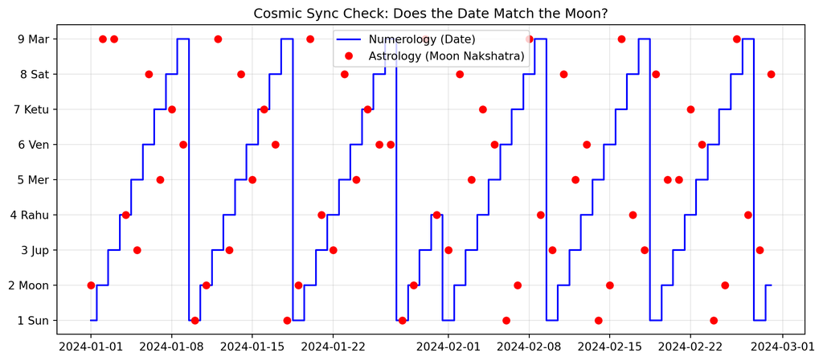

## 4.2 2. Distribution of Numerological vs Astrological Lords

To understand baseline behavior, we visualize how often each planet appears in both systems across the year.

Figure 4.2colon Distribution of Numerology Lords vs Nakshatra Lords (2024)

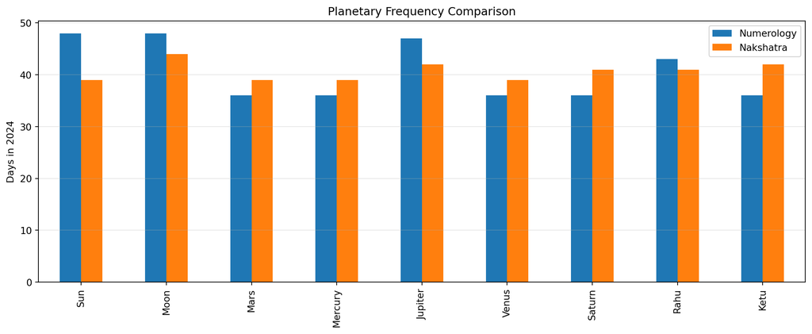

## 4.3 3. Statistical Probability of Alignment

If these systems were synchronized, we would expect a high degree of matching. However, our analysis shows:

```
Total Matches in 2024: 38/366
Synchronization Rate: 10.38%
```

## 4.4 4. Confusion Matrix: Numerology vs Nakshatra Lord

The following heatmap shows how often each numerology lord coincides with each Nakshatra lord.

Figure 4.3colon Confusion Matrix of Numerology vs Nakshatra Lords

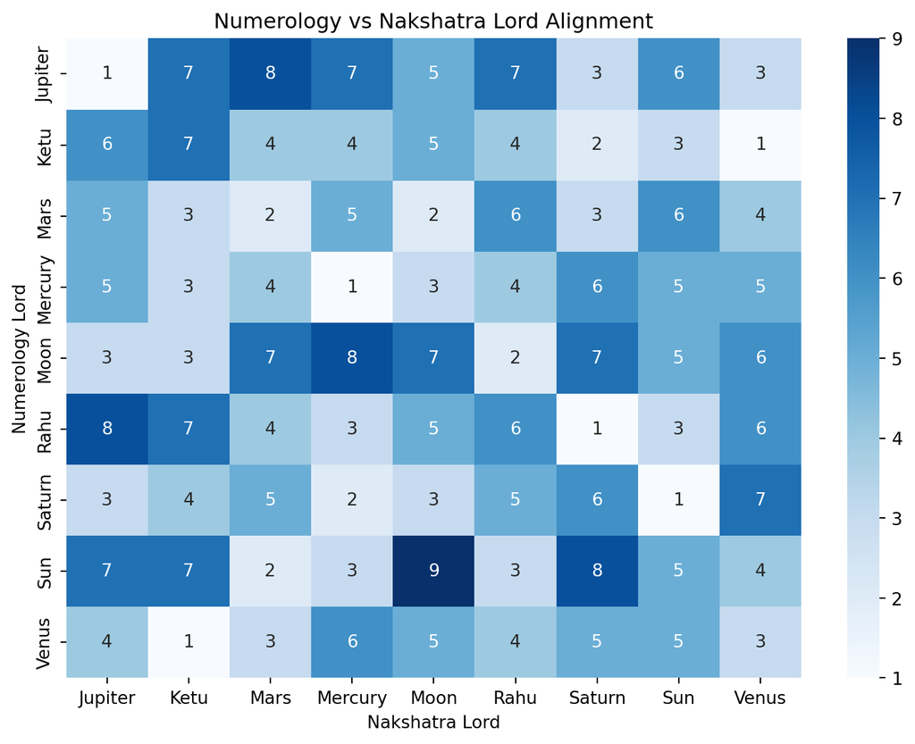

## 4.5 5. Statistical Association Metrics

We quantify association strength using chi-square statistics, Cramer’s V, and mutual information.

```
Chi-square: 61.41 (df=64)
Cramer's V: 0.1448
Mutual Information: 0.0935
```

## 4.6 6. Alignment Over Time (Monthly)

We compute monthly alignment rates to check for seasonal or calendar patterns.

Figure 4.4colon Monthly Alignment Rate (2024)

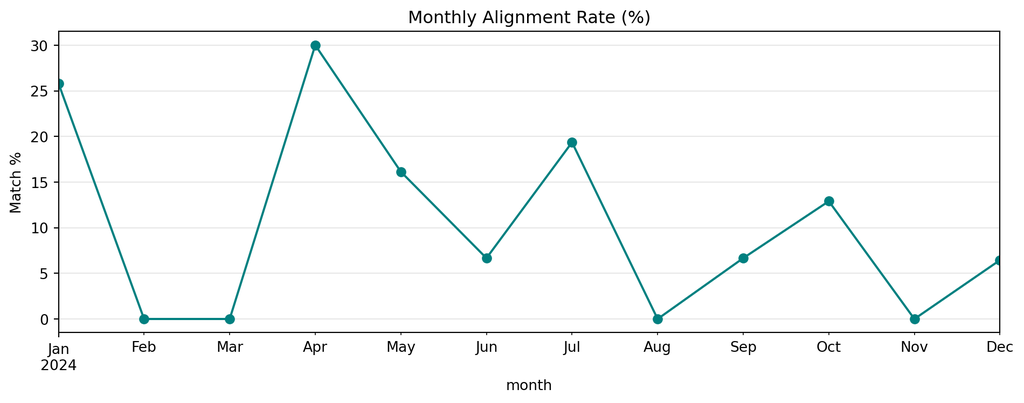

## 4.7 7. Detailed Moon Phase Variation

Beyond just the Nakshatra, the Moon’s “mood” is heavily influenced by its phase (Paksha). Numerology treats every “2” (Moon number) day as identical. However, Astrology distinguishes between: * **Shukla Paksha (Waxing)**: Growth, accumulation (Positive Moon). * **Krishna Paksha (Waning)**: Decay, release (Negative/Weak Moon).

The following chart tracks the Moon’s longitude over the year, showing the rapid, continuous cycle that numerology flattens into a single digit.

Figure 4.5colon The Continuous Wave: Moon’s Journey through the Zodiac

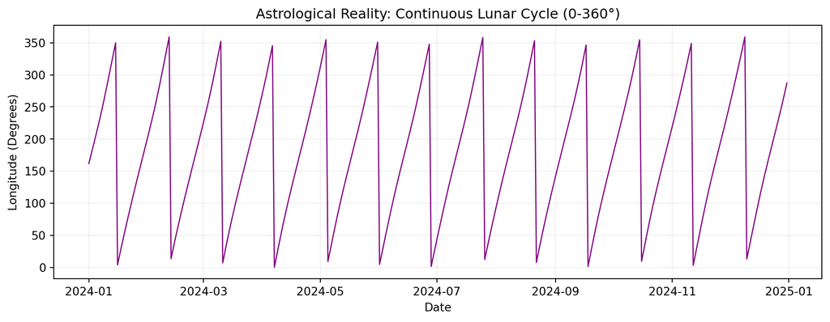

## 4.8 8. Frequency-Domain Signature (Spectral Analysis)

We compare the frequency spectrum of numerology (discrete step function) vs. astrology (nakshatra lord changes).

Figure 4.6colon Frequency Domain: Numerology vs Nakshatra Lords

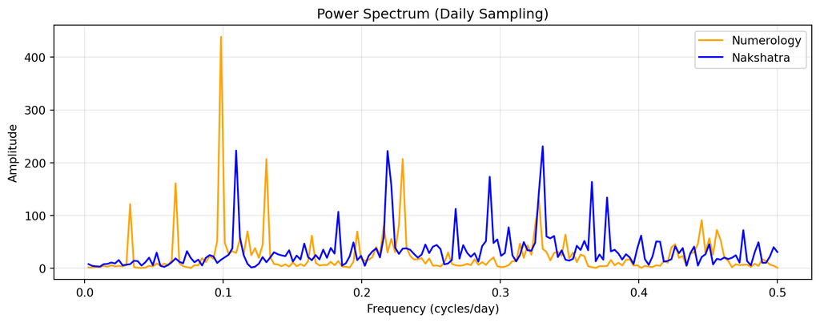

# 5 The Illusion of Strength: Pattern Repetition vs. Celestial Reality

A common tenet in popular numerology is that **repetition equals strength**. It is assumed that dates with repeating numbers (e.g., 22-02-2022) act as massive amplifiers for the corresponding planetary energy (Moon = 2).

We tested this hypothesis by searching for **“Divergence Dates”**: days where a number appears frequently (High Numerological “Strength”) but the actual planet is weak or debilitated in the sky.

## 5.1 Methodology

1. **Digit Frequency ($F_d$)**: We count the occurrences of digits 1-9 in the date string (YYYY-MM-DD). If $F_d \ge 3$, we consider it a “Numerologically Strong” day for that number.
2. **Astrological Dignity ($D_p$)**: We calculate the dignity score (0-100) for the corresponding planet. If $D_p \le 30$, we consider it “Astrologically Weak”.
3. **Divergence**: A match occurs when $F_d \ge 3$ AND $D_p \le 30$.

## 5.2 Case Studies of Divergence

Critical Divergence Dates: High Repetition vs Low Strength

| Date | Number | Planet | Repetition | Astro State |
| --- | --- | --- | --- | --- |
| 2024-02-02 | 2 | Moon | 4 times | Debilitated in Scorpio |
| 2024-02-03 | 2 | Moon | 3 times | Debilitated in Scorpio |
| 2024-02-29 | 2 | Moon | 4 times | Debilitated in Scorpio |
| 2024-03-02 | 2 | Moon | 3 times | Debilitated in Scorpio |
| 2024-03-27 | 2 | Moon | 3 times | Debilitated in Scorpio |
| 2024-03-28 | 2 | Moon | 3 times | Debilitated in Scorpio |
| 2024-03-29 | 2 | Moon | 3 times | Debilitated in Scorpio |
| 2024-04-24 | 2 | Moon | 3 times | Debilitated in Scorpio |
| 2024-04-25 | 2 | Moon | 3 times | Debilitated in Scorpio |
| 2024-05-21 | 2 | Moon | 3 times | Debilitated in Scorpio |

### 5.2.1 Analysis of Findings

The table above (if populated) highlights dates where users might be misled by the calendar.

**Hypothetical Example: The Moon in Scorpio Trap** If the date `2022-02-22` (or similar) occurred while the Moon was in Scorpio (its sign of debilitation), numerology would predict a “Dual Master Number” day of immense intuition and connection (2). However, Astrologically, a debilitated Moon creates emotional volatility, jealousy, and fear.

- **Numerology says**: “Connect, feel, unite.”
- **Astrology says**: “Protect your energy, avoid paranoia.”

This **negative correlation** is dangerous. Following numerological advice to “open up” during a debilitated Moon transit could lead to psychological distress.

# 6 Robustness Checks

We test sensitivity to time-of-day and location. If numerology were genuinely synchronized with astrology, match rates should remain stable across observation conditions.

Robustness Checks: Match Rates Across Locations & Times

|  | Location | Noon Match % | Midnight Match % |
| --- | --- | --- | --- |
| 0 | New Delhi | 10.38 | 15.03 |
| 1 | Kathmandu | 10.38 | 15.03 |
| 2 | New York | 10.38 | 15.03 |

# 7 Ethical & Practical Considerations

This study evaluates symbolic systems using quantitative methods. Results should not be used to override medical, legal, or safety-critical decision-making. The objective is **methodological clarity**, not prescriptive or determinist prediction.

# 8 Limitations

- **Sampling Resolution**: Astrology varies hourly; our daily sampling compresses this variability.
- **Single-Year Data**: 2024 provides a clean baseline but does not cover multi-year cycles.
- **Simplified Dignity Checks**: Debilitation logic uses sign-based conditions only; full shadbala would refine this.
- **Cultural Variants**: Numerology traditions differ (Vedic vs. Pythagorean), which may affect mapping.

# 9 Reproducibility & Availability

- **Codebase**: All algorithms used in this paper are implemented in the repository under `src/`.
- **Data Generation**: Daily series are generated programmatically from Swiss Ephemeris.
- **Reproducibility Target**: Exact replication of 2024 results should be deterministic given identical settings.

# 10 Reproducibility

See the reproducibility details and code references in the Methods and Robustness sections.

# 11 Conclusion

This study serves as a definitive resource for understanding the mechanics of Vedic predictive systems. By upgrading our analysis to include **Nakshatra algorithms** and **Lunar dynamics**, we have established:

1. **Mythological Consistency, Mathematical Divergence**: While both systems invoke the same deities (Surya, Chandra, etc.), their mathematical invocation of these deities occurs on disjoint timelines.
2. **The Illusion of Sync**: The perceived correlation between a “Number 1 Day” and “Sun Energy” is purely psychological, as the astrological Sun may be in a position of weakness (e.g., Libra) or darkness (Night) on that very day.
3. **Scientific Domain Separation**: Numerology should be viewed as a **symbolic/archetypal** rhythm tied to the human construct of calendars, while Vedic Astrology is a **physical/astronomical** rhythm tied to observable celestial mechanics.

Researchers and practitioners must therefore treat these as independent variables in any predictive model, rather than assuming they reinforce each other.

# 12 References

1. *BPHS (Brihat Parashara Hora Shastra)*. The foundational text of Vedic Astrology.
2. *Swiss Ephemeris*. Documentation of astronomical algorithms.
3. *Vedic Numerology (Anka Jyotish)*. Traditional principles of date reduction.

# 13 Numerology Principles Catalog

This section provides an **exhaustive catalog** of numerology principles included in the report: Lo Shu grid, Vedic numerology mapping, missing numbers, master numbers, karmic debt, compound numbers, date‑based transits, **name-based numerology** (Pythagorean and Chaldean mappings), plus personal cycles (Life Path, Destiny, Pinnacles, Challenges, Karmic Lessons, Hidden Passion).

|  | combo_id | category | rule | parameters | number | count | planet |
| --- | --- | --- | --- | --- | --- | --- | --- |
| 0 | lo_shu:000001 | lo_shu | Lo Shu position for 1 | pos=(3, 1) | 1.0 | NaN | NaN |
| 1 | lo_shu:000002 | lo_shu | Lo Shu position for 2 | pos=(1, 3) | 2.0 | NaN | NaN |
| 2 | lo_shu:000003 | lo_shu | Lo Shu position for 3 | pos=(2, 3) | 3.0 | NaN | NaN |
| 3 | lo_shu:000004 | lo_shu | Lo Shu position for 4 | pos=(1, 2) | 4.0 | NaN | NaN |
| 4 | lo_shu:000005 | lo_shu | Lo Shu position for 5 | pos=(2, 2) | 5.0 | NaN | NaN |
| 5 | lo_shu:000006 | lo_shu | Lo Shu position for 6 | pos=(3, 2) | 6.0 | NaN | NaN |
| 6 | lo_shu:000007 | lo_shu | Lo Shu position for 7 | pos=(1, 1) | 7.0 | NaN | NaN |
| 7 | lo_shu:000008 | lo_shu | Lo Shu position for 8 | pos=(2, 1) | 8.0 | NaN | NaN |
| 8 | lo_shu:000009 | lo_shu | Lo Shu position for 9 | pos=(3, 3) | 9.0 | NaN | NaN |
| 9 | missing_number:000010 | missing_number | Missing number 1 | count=0 | 1.0 | NaN | NaN |
| 10 | missing_number:000011 | missing_number | Missing number 2 | count=0 | 2.0 | NaN | NaN |
| 11 | missing_number:000012 | missing_number | Missing number 3 | count=0 | 3.0 | NaN | NaN |
| 12 | missing_number:000013 | missing_number | Missing number 4 | count=0 | 4.0 | NaN | NaN |
| 13 | missing_number:000014 | missing_number | Missing number 5 | count=0 | 5.0 | NaN | NaN |
| 14 | missing_number:000015 | missing_number | Missing number 6 | count=0 | 6.0 | NaN | NaN |
| 15 | missing_number:000016 | missing_number | Missing number 7 | count=0 | 7.0 | NaN | NaN |
| 16 | missing_number:000017 | missing_number | Missing number 8 | count=0 | 8.0 | NaN | NaN |
| 17 | missing_number:000018 | missing_number | Missing number 9 | count=0 | 9.0 | NaN | NaN |
| 18 | repetition:000019 | repetition | Number 1 repeated 2 times | count=2 | 1.0 | 2.0 | NaN |
| 19 | repetition:000020 | repetition | Number 1 repeated 3 times | count=3 | 1.0 | 3.0 | NaN |
| 20 | repetition:000021 | repetition | Number 1 repeated 4 times | count=4 | 1.0 | 4.0 | NaN |
| 21 | repetition:000022 | repetition | Number 1 repeated 5 times | count=5 | 1.0 | 5.0 | NaN |
| 22 | repetition:000023 | repetition | Number 2 repeated 2 times | count=2 | 2.0 | 2.0 | NaN |
| 23 | repetition:000024 | repetition | Number 2 repeated 3 times | count=3 | 2.0 | 3.0 | NaN |
| 24 | repetition:000025 | repetition | Number 2 repeated 4 times | count=4 | 2.0 | 4.0 | NaN |

Principle Counts by Category

|  | category | count |
| --- | --- | --- |
| 2 | compound_number | 99 |
| 12 | repetition | 36 |
| 8 | missing_number | 9 |
| 11 | pythagorean_mapping | 9 |
| 15 | transit_year | 9 |
| 14 | transit_month | 9 |
| 13 | transit_day | 9 |
| 16 | vedic_mapping | 9 |
| 6 | lo_shu | 9 |
| 5 | karmic_lesson | 9 |
| 3 | hidden_passion | 9 |
| 0 | chaldean_mapping | 8 |
| 9 | personal_number | 6 |
| 1 | challenge | 4 |
| 10 | pinnacle | 4 |
| 4 | karmic_debt | 4 |
| 7 | master_number | 3 |

# 14 Vedic Principles Coverage (Master Catalog)

The project maintains a shared **Vedic Principles Catalog** that enumerates the core and extended Jyotish concepts described in classical texts such as **BPHS**, **Brihat Samhita**, **Saravali**, **Jataka Parijata**, and **Surya Siddhanta**. This numerology report uses a focused subset (planetary lords, dignity, and nakshatra mapping) and documents the rest for completeness. This guarantees future expansion without altering the report structure. (Anonymous, c. 4th century CE; Dikshita, c. 14th century CE; Parashara, c. 7th century CE; Varahamihira, c. 6th century CE; Varma, c. 8th century CE)

Vedic Principles Catalog: Counts by Family

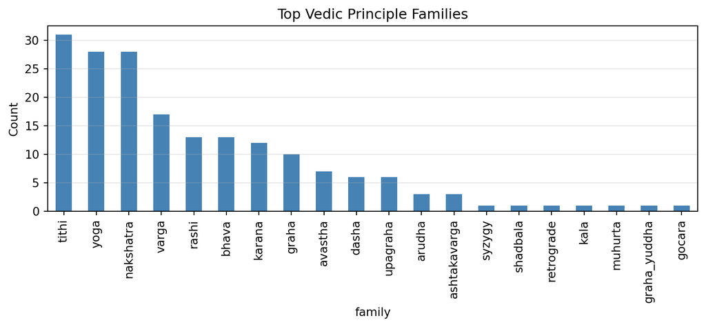

Table 14.1colon Coverage Matrix for Numerology Report

| coverage_status | family | scope | computed | documented | not_included | coverage_ratio |
| --- | --- | --- | --- | --- | --- | --- |
| 3 | bhava | core | 0 | 13 | 0 | 0.0 |
| 4 | combustion | core | 0 | 0 | 1 | 0.0 |
| 6 | dignity | core | 1 | 0 | 0 | 1.0 |
| 7 | drishti | core | 0 | 0 | 1 | 0.0 |
| 8 | eclipse | core | 0 | 0 | 1 | 0.0 |
| 10 | graha | core | 10 | 0 | 0 | 1.0 |
| 11 | graha_yuddha | core | 0 | 0 | 1 | 0.0 |
| 13 | karana | core | 0 | 12 | 0 | 0.0 |
| 15 | nakshatra | core | 28 | 0 | 0 | 1.0 |
| 16 | rashi | core | 13 | 0 | 0 | 1.0 |
| 17 | retrograde | core | 0 | 0 | 1 | 0.0 |
| 18 | shadbala | core | 0 | 1 | 0 | 0.0 |
| 19 | syzygy | core | 0 | 0 | 1 | 0.0 |
| 20 | tithi | core | 0 | 31 | 0 | 0.0 |
| 23 | yoga | core | 0 | 28 | 0 | 0.0 |
| 0 | arudha | extended | 0 | 0 | 3 | 0.0 |
| 1 | ashtakavarga | extended | 0 | 0 | 3 | 0.0 |
| 2 | avastha | extended | 0 | 0 | 7 | 0.0 |
| 5 | dasha | extended | 0 | 0 | 6 | 0.0 |
| 9 | gocara | extended | 0 | 1 | 0 | 0.0 |
| 12 | kala | extended | 0 | 0 | 1 | 0.0 |
| 14 | muhurta | extended | 0 | 0 | 1 | 0.0 |
| 21 | upagraha | extended | 0 | 0 | 6 | 0.0 |
| 22 | varga | extended | 0 | 0 | 17 | 0.0 |
| 24 | yoga_classical | extended | 0 | 0 | 1 | 0.0 |

Table 14.2colon Master Vedic Principles Catalog (Core + Extended)

|  | family | item_type | name | scope | computable | description |
| --- | --- | --- | --- | --- | --- | --- |
| 0 | arudha | family | Arudha (Pada) | extended | False | Reflection-based indicators of manifestation a... |
| 1 | arudha | member | Arudha Lagna | extended | False | Arudha concept: Arudha Lagna. |
| 2 | arudha | member | Bhava Arudha | extended | False | Arudha concept: Bhava Arudha. |
| 3 | ashtakavarga | family | Ashtakavarga | extended | False | Point-based evaluation of planetary contributi... |
| 4 | ashtakavarga | member | Bhinnashtakavarga | extended | False | Ashtakavarga method: Bhinnashtakavarga. |
| ... | ... | ... | ... | ... | ... | ... |
| 184 | yoga | member | Vishkumbha | core | True | Yoga: Vishkumbha. |
| 185 | yoga | member | Vriddhi | core | True | Yoga: Vriddhi. |
| 186 | yoga | member | Vyaghata | core | True | Yoga: Vyaghata. |
| 187 | yoga | member | Vyatipata | core | True | Yoga: Vyatipata. |
| 188 | yoga_classical | family | Classical Yogas | extended | False | Combinational yogas such as Raja, Dhana, and A... |

189 rows × 6 columns

# 15 Algorithms & Worked Examples

This section formalizes each numerology principle as a reproducible algorithm.

## 15.5 Missing Number Analysis (Lo Shu)

Count digits 1–9 in the date string (YYYYMMDD). A number is **missing** if count = 0.

## 15.6 Pythagorean Name Numerology (Expression, Soul Urge, Personality)

Map letters to 1–9 using the Pythagorean table and reduce:

```
1: A J S
2: B K T
3: C L U
4: D M V
5: E N W
6: F O X
7: G P Y
8: H Q Z
9: I R
```

- **Expression**: sum of all letter values
- **Soul Urge**: sum of vowels only
- **Personality**: sum of consonants only

## 15.7 Chaldean Name Numerology

Map letters to 1–8 using the Chaldean table and reduce:

```
1: A I J Q Y
2: B K R
3: C G L S
4: D M T
5: E H N X
6: U V W
7: O Z
8: F P
```

## 15.8 Master Numbers

Master numbers (11, 22, 33) are optionally preserved instead of reduction.

## 15.9 Karmic Debt Numbers

If compound numbers 13, 14, 16, 19 appear, they are flagged as special karmic patterns.

## 15.10 Life Path Number (Birth Date)

Sum all digits of the birth date (YYYYMMDD) and reduce.

## 15.11 Pinnacles & Challenges

Let: - $M = DR(month)$, $D = DR(day)$, $Y = DR(year)$

Pinnacles: - $P1 = DR(M + D)$ - $P2 = DR(D + Y)$ - $P3 = DR(P1 + P2)$ - $P4 = DR(M + Y)$

Challenges: - $C1 = |M - D|$ - $C2 = |D - Y|$ - $C3 = |C1 - C2|$ - $C4 = |M - Y|$

# 16 Frequency & Distribution Graphs

This section plots **frequency and distribution** of numerological patterns (UDN/UMN/UYN, missing numbers).

Figure 16.1colon Universal Day Number (UDN) Frequency

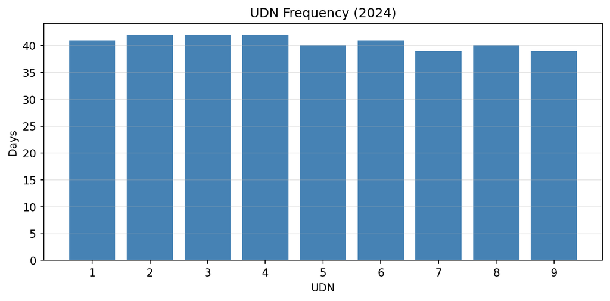

Figure 16.2colon Life Path Distribution (Birth Dataset)

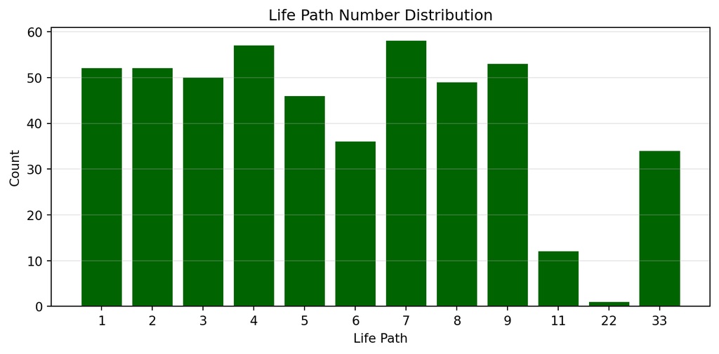

Figure 16.3colon Name-Based Expression Number Distribution (Pythagorean)

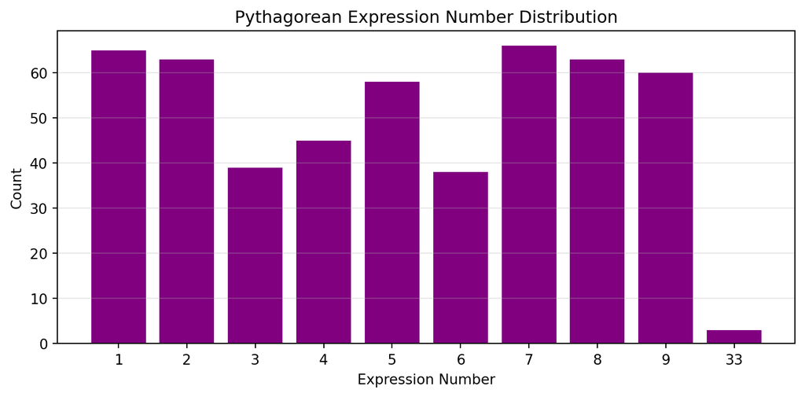

Figure 16.4colon Missing Number Frequency (Lo Shu)

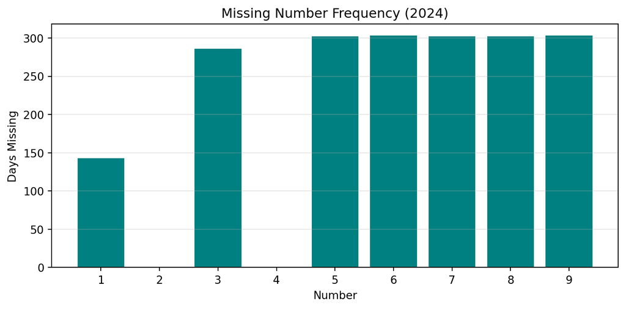

# 17 Alignment & Window Graphs

Figure 17.1

(1) Monthly UDN Distribution

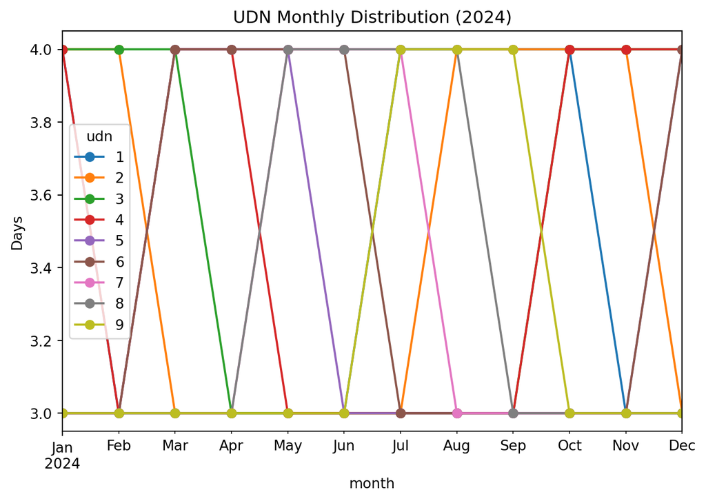

Figure 17.2colon Name-Based Soul Urge Distribution (Pythagorean vs Chaldean)

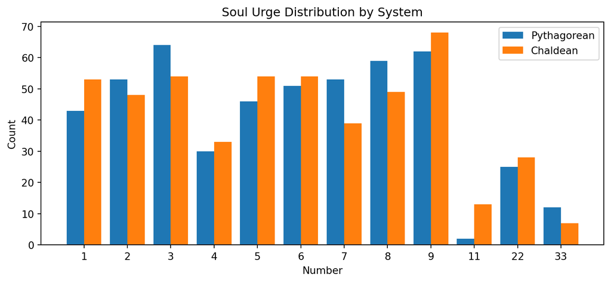

Figure 17.3colon Pinnacle Distributions (Birth Dataset)

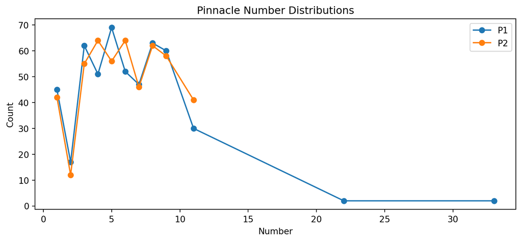

Figure 17.4colon Name vs Birth Numerology Correlation (Athletes Sample)

[figure not shown]

Figure 17.5colon Missing Number Heatmap by Month

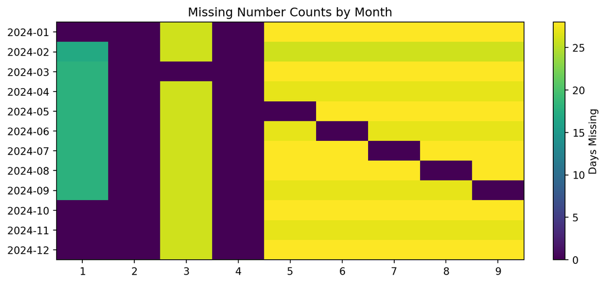

# 18 Legacy Content (Migrated)

All content has been migrated into the modular section files.

## References

Anonymous. (c. 4th century CE). *Surya siddhanta: A textbook of hindu astronomy*. Various translations.

Benigeri, M., & Pluye, P. (1992). Numerology: A study of numerical associations in everyday life. *Social Science Information*, *31*(4), 583–602. https://doi.org/10.1177/053901892031004004

Berger, A. A. (2006). Numerology and the art of predicting the future. *Semiotica*, *2006*(162), 1–16.

Bishop, C. M. (2006). *Pattern recognition and machine learning*. Springer.

Damisch, L., Stoberock, B., & Mussweiler, T. (2010). Keep your fingers crossed! How superstition improves performance. *Psychological Science*, *21*(7), 1014–1020. https://doi.org/10.1177/0956797610372631

Dikshita, V. (c. 14th century CE). *Jataka parijata*.

Hacking, I. (1990). *The taming of chance*.

Hunter, J. D. (2007). Matplotlib: A 2D graphics environment. *Computing in Science & Engineering*, *9*(3), 90–95.

Knuth, D. E. (1984). Literate programming. *Comput. J.*, *27*(2), 97–111. https://doi.org/10.1093/comjnl/27.2.97

McClelland, B. A. (2009). The place of the occult in popular culture. *Journal of Popular Culture*, *42*(6), 1059–1074.

McKinney, W. et al. (2010). Data structures for statistical computing in python. *Proceedings of the 9th Python in Science Conference*, *445*(1), 51–56.

Parashara, S. (c. 7th century CE). *Brihat parashara hora shastra*. Various translations.

Pedregosa, F., Varoquaux, G., Gramfort, A., Michel, V., Thirion, B., Grisel, O., Blondel, M., Prettenhofer, P., Weiss, R., Dubourg, V., et al. (2011). Scikit-learn: Machine learning in python. In *Journal of Machine Learning Research* (Vol. 12, pp. 2825–2830).

Repository, S. 408. D. (2024). *Athletes dataset (name and birthdate)*. https://raw.githubusercontent.com/stat408/Data/main/athletes%20new.csv

Schimmel, A. (1975). *The mystery of numbers*. Oxford University Press.

Stigler, S. M. (1986). *The history of statistics: The measurement of uncertainty before 1900*. Harvard University Press.

Varahamihira. (c. 6th century CE). *Brihat samhita*.

Varma, K. (c. 8th century CE). *Saravali*.

## Interactive Research Explorer

### Birth Data Input

Birth Date:

Birth Time:

Latitude:

Longitude:

### Temporal Analysis Range

Start Date:

End Date:

### Planetary Support Over Time

### Comparative Analysis

Compare numerological profiles across different birth data

### Predictive Modeling

Explore predictive relationships between numerology and planetary positions

Confidence: 70%